# MDD MWAS - comparison between smoking variables

Miruna Barbu

13/05/2021

#### **3 ways to predict smoking using EpiSmoker**

Source article: https://doi.org/10.2217/epi-2019-0206

There are 3 options to estimate smoking status using EpiSmoker, all derived from whole blood 450K array:

1. **Smoking status**

Uses 121 CpGs to predict smoking status of each individual (LASSO approach). Sex and intercept derived from study are also used in the calculation.

Bollepalli et al. developed EpiSmokEr (Epigenetic Smoking status Estimator), an easy-to-use R package to facilitate the prediction of smoking status. Given methylation data from microarray assays, it provides predicted smoking status as an output. EpiSmokEr can be run not only on whole datasets, but also on isolated individual samples. To be comprehensive, Bollepalli et al. also provide functions for computing SSc and MS.

N=86/121 of CpGs are available in GS.

2. **Smoking score**

Uses 187 smoking-associated CpGs identified in Zeilinger et al., 2013 (https://doi.org/10.1371/journal.pone.0063812) and calculated using method from Elliott et al., 2014 (https://doi.org/10.1186/1868-7083-6-4)

Elliot et al. have suggested calculating a weighted score referred to as ‘smoking score’ by adding up the methylation levels of the 187 CpG sites found to be significantly associated with smoking by Zellinger et al., after first multiplying each methylation value by its effect size in Zellinger et al.’s EWAS study.

**Study population in Zeilinger et al.: KORA S4**

N=165/187 of CpGs are available in GS.

3. **Methylation score**

Uses 4 smoking-associated CpGs identified in Zhang et al., 2016 (https://doi.org/10.1016/j.envres.2016.01.026)

Zhang et al. used a regression approach. They first determined significantly associated CpG sites in their cohort, and then employed stepwise logistic regression with forward selection. They used a significance-based stopping criterion and found that already after including the **four most significant loci**, the addition of the fifth locus no longer resulted in a significant reduction of the fit deviance. Therefore, their proposed ‘methylation score’ only requires **four CpG sites**.

N=2/4 of CpGs are available in GS.

#### Descriptive statistics

Predicted smoking status, mean smoking score, and mean methylation score for current, former, and never smokers in GS.

| GS.smoking.status | n | Predicted.smoking.status | Smoking.score.mean | Methylation.score.mean |
| --- | --- | --- | --- | --- |
| Current smoker | 1620 | Current Smoker | 8.584973 | 2.913198 |
| Former smoker (stopped < 12 months) | 274 | Current Smoker | 6.914629 | 2.825632 |
| Former smoker (stopped > 12 months) | 2604 | Current Smoker | 5.117609 | 2.579194 |
| Never smoker | 4787 | Current Smoker | 4.060137 | 2.363031 |

#### Possible issues with calculating these in different cohorts

- M-values required for MWAS, but beta values required for EpiSmoker calculation
- Different cohorts will have different CpGs available for calculation
- Required to extract each set of CpGs for Epismoker

#### **Comparing smoking signatures across MWAS - MDD**

5 basic models were run, with technical and biological covariates accounted for. CpGs were included as outcomes and MDD diagnosis as the predictor variable, with:

1. no smoking covariate
2. phenotypic smoking (current, former, never smokers)
3. AHRR probe (cg05575921)
4. EpiSmoker smoking-derived score (based on 165/187 CpGs)
5. EpiSmoker methylation-derived smoking score (based on 2/4 CpGs).

#### **Comparing statistics across MWAS - MDD**

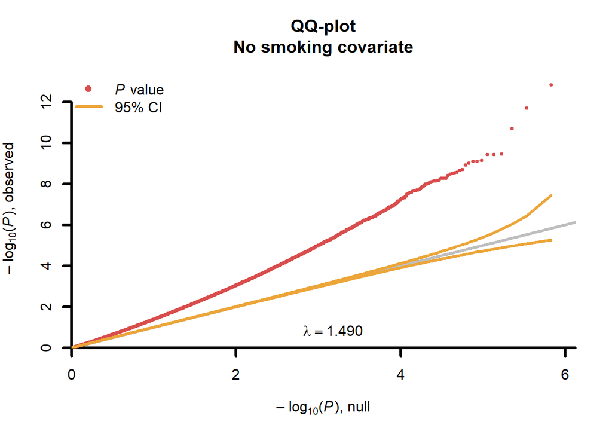

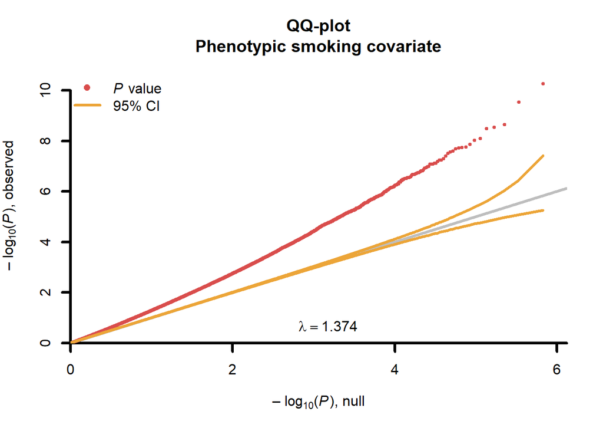

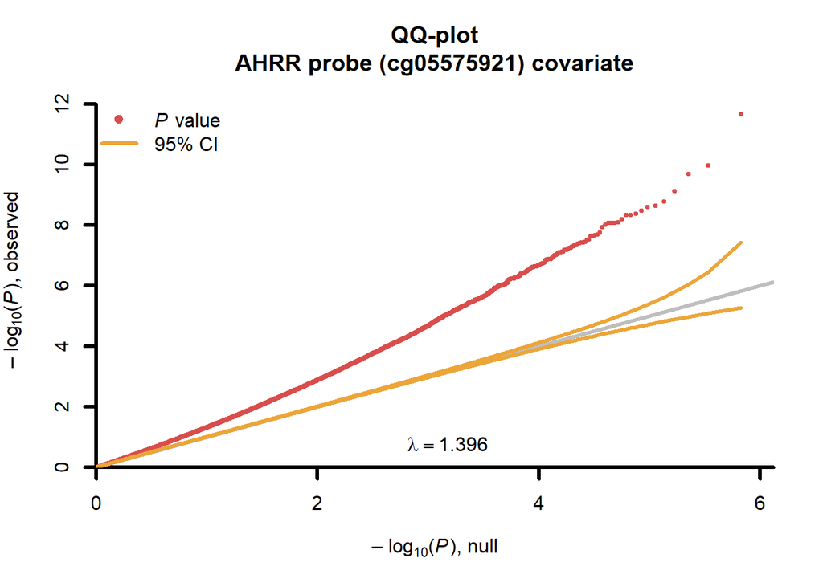

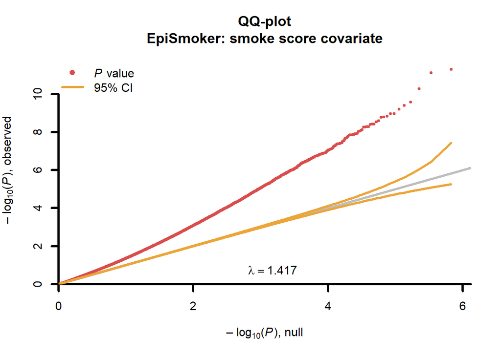

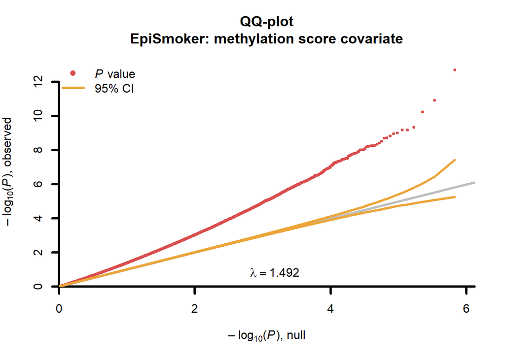

Variance inflation factor, number of Bonferroni-corrected CpGs, minimum p-value, and minimum & maximum effect sizes for every MWAS based on smoking covariate included. All models are corrected for technical and biological covariates.

| Covariate included in MWAS | lambda | N Bonferroni-corrected CpGs | Min p-value | Min effect size | Max effect size |
| --- | --- | --- | --- | --- | --- |
| Phenotypic smoking | 1.374 | 15 | 5.38433595238757e-11 | -0.040 | 0.050 |
| AHRR probe (cg05575921) | 1.396 | 26 | 2.07051685731157e-12 | -0.041 | 0.051 |
| EpiSmoker smoke score | 1.417 | 42 | 4.85097353029382e-12 | -0.040 | 0.055 |
| No smoking covariate | 1.49 | 57 | 1.45303929463449e-13 | -0.050 | 0.055 |
| EpiSmoker methylation score | 1.492 | 46 | 1.9299926391313e-13 | -0.050 | 0.054 |

#### **Correlation between AHRR probe (cg05575921) and EpiSmoker smoking score**

```
## [1] -0.8983258
```

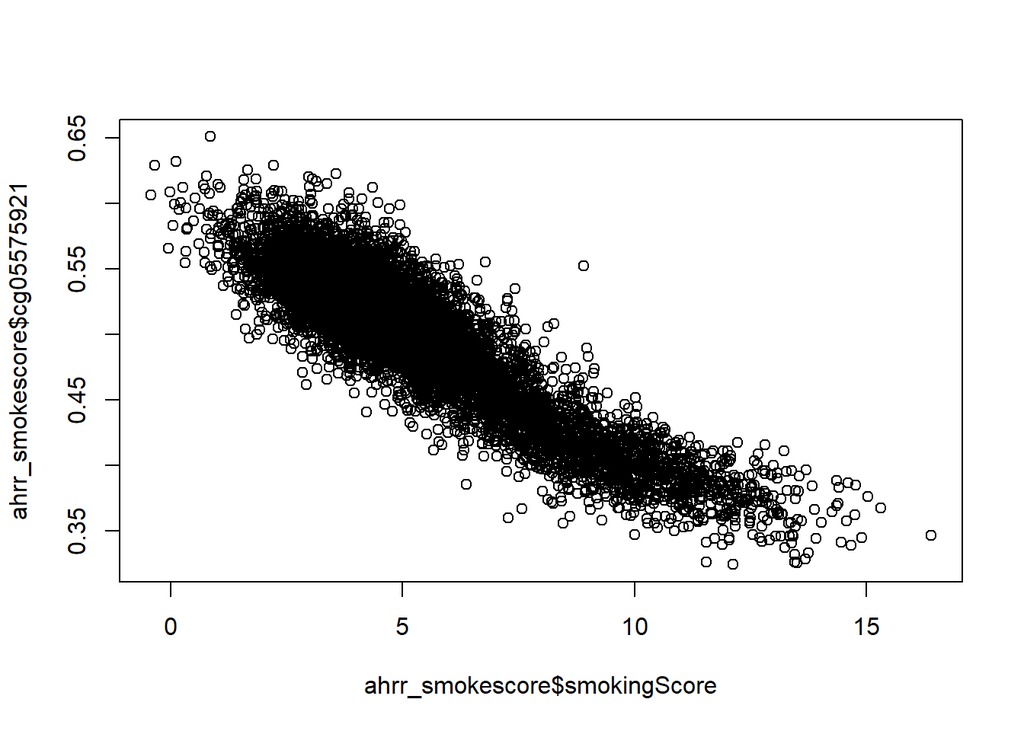

#### Check MDD MWAS results against Joehanes et al. FDR-corrected CpGs

Number of Bonferroni-corrected CpGs, minimum p-value, and overlapping top CpGs with Joehanes et al. FDR-corrected CpGs for every MDD MWAS based on smoking covariate included. All models are corrected for technical and biological covariates.

| Covariate included in MWAS | N Bonferroni-corrected CpGs | Min p-value | Overlapping CpGs with Joehanes et al. |
| --- | --- | --- | --- |
| Phenotypic smoking | 15 | 5.38433595238757e-11 | 0 |
| AHRR probe (cg05575921) | 26 | 2.07051685731157e-12 | 0 |
| EpiSmoker smoke score | 42 | 4.85097353029382e-12 | 0 |
| EpiSmoker methylation score | 46 | 1.9299926391313e-13 | 9 |
| No smoking covariate | 57 | 1.45303929463449e-13 | 15 |

#### MWAS for trait associated with smoking - educational attainment

#### **Comparing statistics across MWAS**

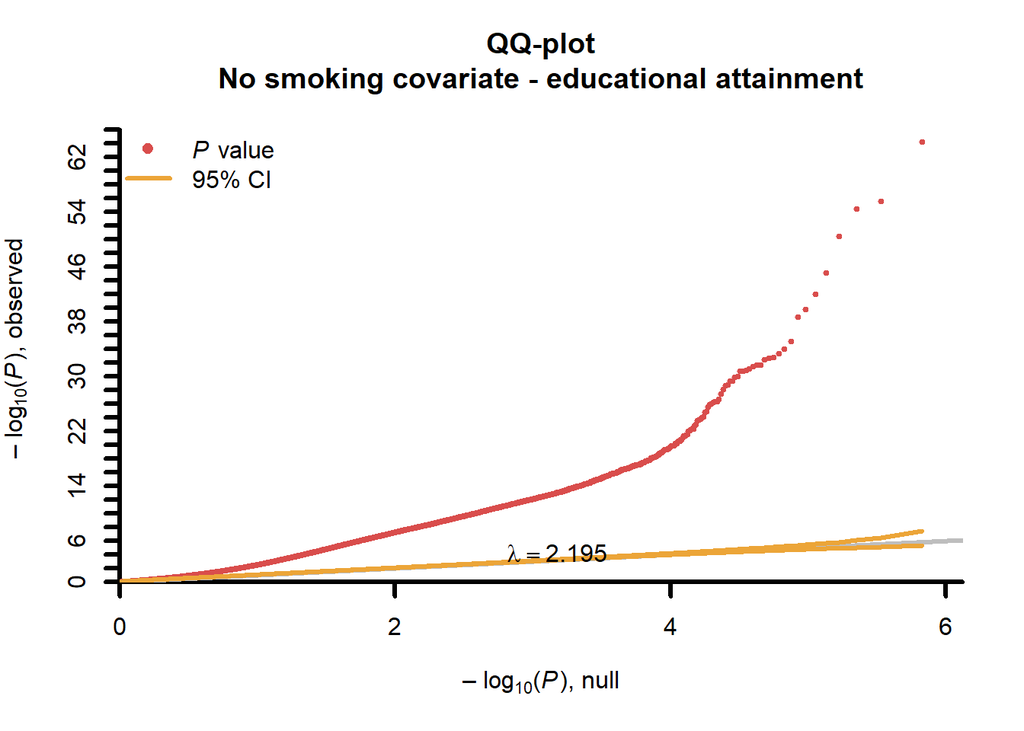

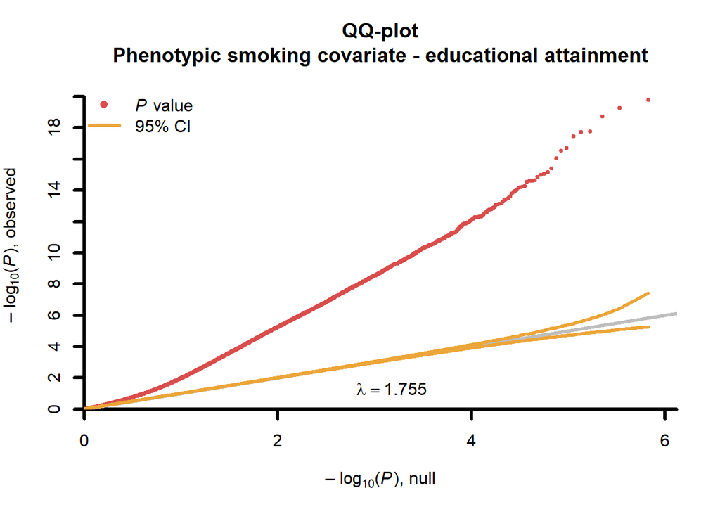

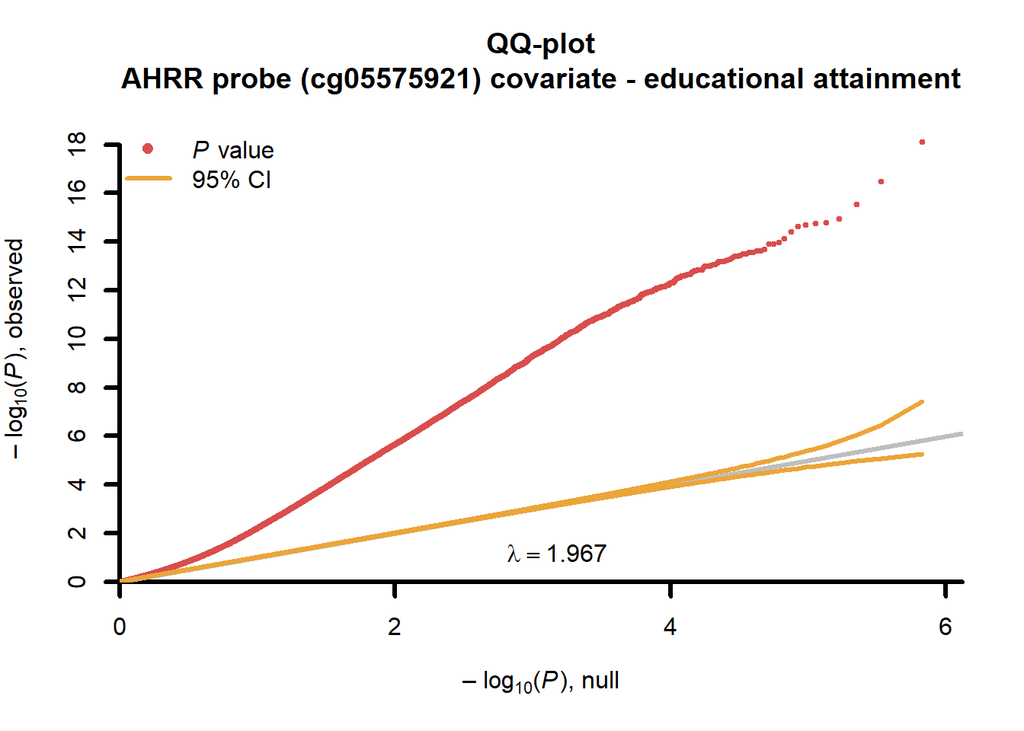

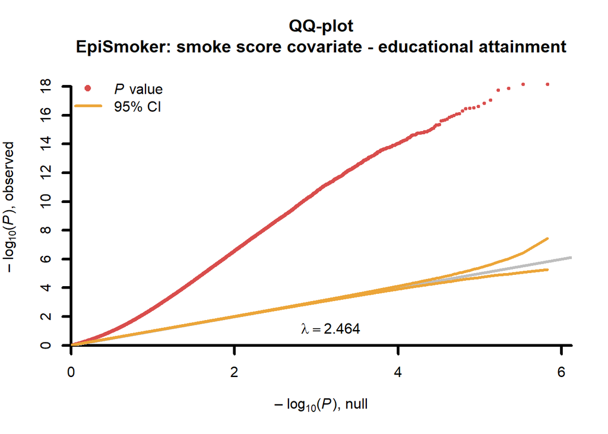

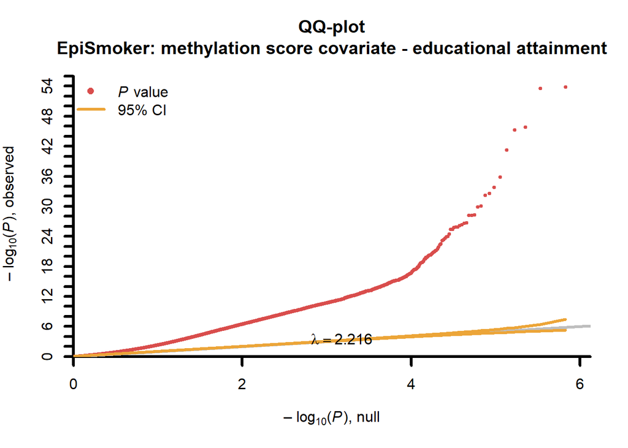

Variance inflation factor, number of Bonferroni-corrected CpGs, minimum p-value, and minimum & maximum effect sizes for every Educational Attainment MWAS based on smoking covariate included. All models are corrected for technical and biological covariates.

| Covariate included in MWAS | lambda | N Bonferroni-corrected CpGs | Min p-value | Min effect size | Max effect size |
| --- | --- | --- | --- | --- | --- |
| Phenotypic smoking | 1.755 | 1468 | 1.57247945788674e-20 | -0.008 | 0.012 |
| AHRR probe (cg05575921) | 1.967 | 2129 | 7.56149718981094e-19 | -0.007 | 0.012 |
| No smoking covariate | 2.195 | 6097 | 6.06704958142841e-65 | -0.021 | 0.016 |
| EpiSmoker methylation score | 2.216 | 4042 | 1.33167029947138e-54 | -0.017 | 0.015 |
| EpiSmoker smoke score | 2.464 | 4182 | 6.7966527419853e-19 | -0.005 | 0.012 |